# Distribuições de probabilidade complementares

Gabriela Neres, Mariane Melo, Pedro Lopes

## 1 Introdução

A diversidade beta representa a variação na composição de espécies entre diferentes locais, refletindo como as comunidades mudam ao longo de gradientes ambientais, espaciais ou temporais. Com base nesse conceito, Legendre & Cáceres (2013) propuseram o LCBD (Local Contribution to Beta Diversity), que mede a singularidade ecológica de uma comunidade dentro de uma metacomunidade, o quanto aquela comunidade “contribui” para a diversidade beta. Valores altos de LCBD indicam locais com espécies raras, composições únicas ou baixa riqueza, destacando comunidades importantes para a manutenção da diversidade regional e úteis para definir áreas prioritárias de conservação e restauração.

Os dados utilizados nesta análise são valores de LCBD de comunidades em algumas metacomunidades de rios. As comunidades podem ser de trechos intermitentes (que podem secar) ou perenes (que não secam) destes rios.

Este script tem como objetivo ajustar modelos lineares generalizados (GLM) para o índice **LCBD total** (Local Contribution to Beta Diversity) para testar se fatores como **tipo de rio (perene ou intermitente)**, **ordem do rio** e variáveis de **uso do solo** são variáveis que descrevem os valores de LCBD em uma determinada metacomunidade.  
O objetivo é utilizar modelos de distribuição beta (valores de LCBD variam entre 0 e 1), verificar a adequação dos modelos e visualizar os resultados.

## 2 Carregando pacotes utilizados

```r
library(dplyr)       # Manipulação de dados
library(ggplot2)     # Visualização de dados
library(glmmTMB)     # Modelos GLM
library(performance) # Diagnóstico de modelos
library(DHARMa)      # Resíduos simulados para GLM
library(ggeffects)   # Predições e gráficos de efeitos
library(usdm)        # VIF
library(corrplot)    # Plot de correlação
```

## 3 Carregando os dados

Leitura do arquivo CSV para obtenção do dataset.

```r
dados <- read.csv(paste0(path, "/output/processed_data/dados_modelos.csv"))

# Estrutura do dataframe
str(dados)
```

```
## 'data.frame':    449 obs. of  18 variables:
##  $ cd_site                  : int  6000890 6000950 6000980 6000990 6000993 6000997 6000998 6001000 6001180 6001190 ...
##  $ metacomm_id              : chr  "U012" "U012" "U012" "U012" ...
##  $ meta_lvl                 : chr  "U0" "U0" "U0" "U0" ...
##  $ year                     : int  2014 2014 2014 2014 2014 2014 2014 2014 2014 2014 ...
##  $ richness                 : int  51 48 52 52 45 49 38 60 45 53 ...
##  $ lcbd_total               : num  0.0139 0.0108 0.0117 0.0104 0.0144 ...
##  $ lcbd_rep                 : num  0.021 0.0114 0.01 0.0151 0.0236 ...
##  $ lcbd_rich                : num  0.00556 0.0092 0.01353 0.0024 0.00339 ...
##  $ type                     : chr  "per" "per" "per" "per" ...
##  $ rang_corr                : int  3 3 3 2 4 3 4 5 3 4 ...
##  $ attr_inter               : num  -0.982 -0.852 -0.783 -0.644 -1.138 ...
##  $ latitude                 : num  1.84 1.92 1.9 1.95 1.84 ...
##  $ longitude                : num  0.241 0.504 0.268 0.39 0.28 ...
##  $ PCT_EXTENSIVE_AGRICULTURE: num  2.342 0.667 2.402 0.61 1.921 ...
##  $ PCT_INTENSIVE_AGRICULTURE: num  -0.36 0.453 -0.422 -0.941 -0.281 ...
##  $ PCT_URBAN                : num  -0.3347 -0.0817 -0.2229 -0.5147 -0.3644 ...
##  $ PCT_NEAR_NATURAL         : num  -0.66 -0.605 -0.675 0.591 -0.523 ...
##  $ RIPAR30M_R               : num  -0.5673 0.0265 -0.7678 1.2244 -0.3499 ...
```

## 4 Ajuste das variáveis

Transformamos colunas categóricas em fatores.

```r
dados[, c("metacomm_id", "cd_site", "meta_lvl", "type")] <-
  lapply(dados[, c("metacomm_id", "cd_site", "meta_lvl", "type")], factor)
```

## 5 Exploração inicial dos dados

Primeiramente filtramos o dataset para avaliarmos apenas os dados de uma metacomunidade: **U012**. Em seguida vamos verificar se há correlação ou VIF elevado em algumas possíveis variáveis preditoras.

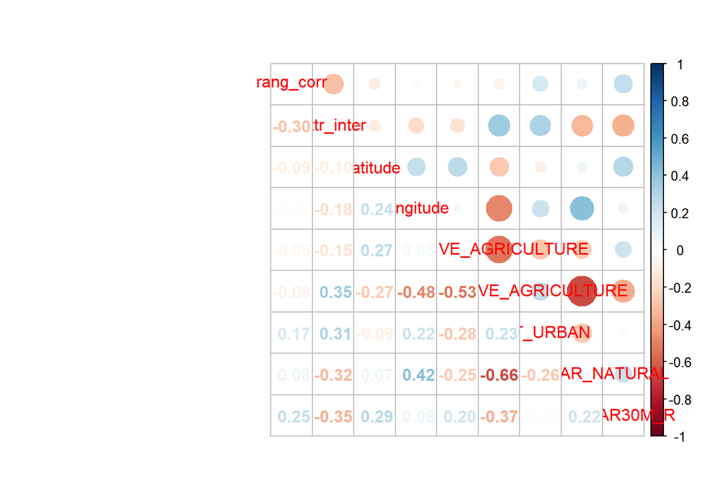

```r
meta <- "U012"
lcbd_meta <- dados %>% filter(metacomm_id == meta)

m_cor <- cor(lcbd_meta[,10:18])
corrplot.mixed(m_cor)
```

```r
vif_var <- vifstep(lcbd_meta[,10:18], th = 5)
vif_var
```

```
## 1 variables from the 9 input variables have collinearity problem:
##
## PCT_EXTENSIVE_AGRICULTURE
##
## After excluding the collinear variables, the linear correlation coefficients ranges between:
## min correlation ( RIPAR30M_R ~ PCT_URBAN ):  -0.02180178
## max correlation ( PCT_NEAR_NATURAL ~ PCT_INTENSIVE_AGRICULTURE ):  -0.6550507
##
## ---------- VIFs of the remained variables --------
##                   Variables      VIF
## 1                 rang_corr 1.305858
## 2                attr_inter 1.566105
## 3                  latitude 1.248660
## 4                 longitude 1.903705
## 5 PCT_INTENSIVE_AGRICULTURE 2.355006
## 6                 PCT_URBAN 1.715106
## 7          PCT_NEAR_NATURAL 1.998715
## 8                RIPAR30M_R 1.450274
```

Agora visualizamos a distribuição do LCBD e sua variação com as variáveis que pretendemos investigar.

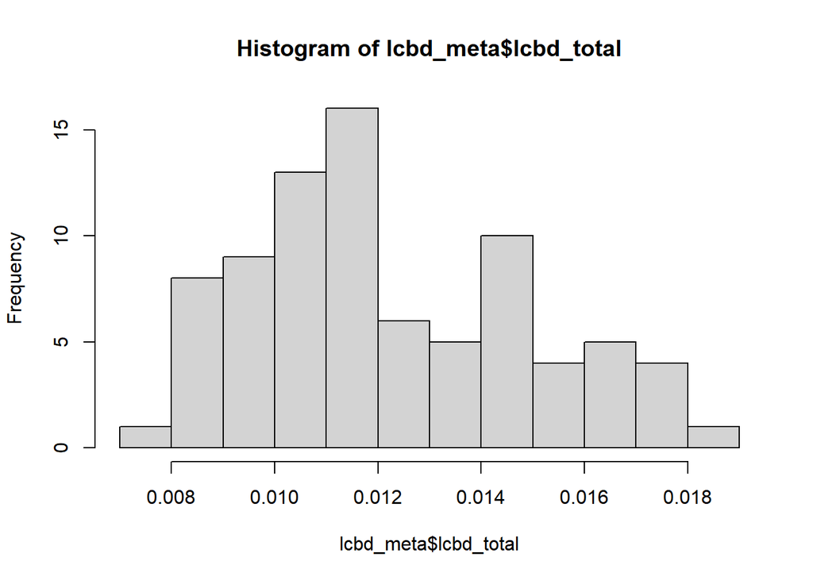

```r
hist(lcbd_meta$lcbd_total)
```

```r
summary(lcbd_meta$lcbd_total)
```

```
##     Min.  1st Qu.   Median     Mean  3rd Qu.     Max.
## 0.007713 0.010116 0.011545 0.012195 0.014417 0.018725
```

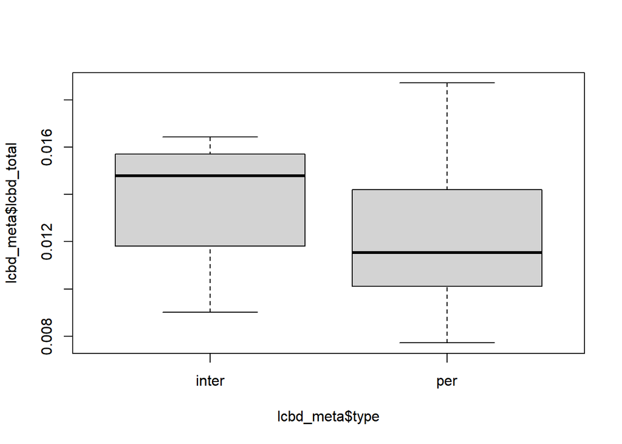

```r
plot(lcbd_meta$lcbd_total ~ lcbd_meta$type) #Rio perene vs. intermitente
```

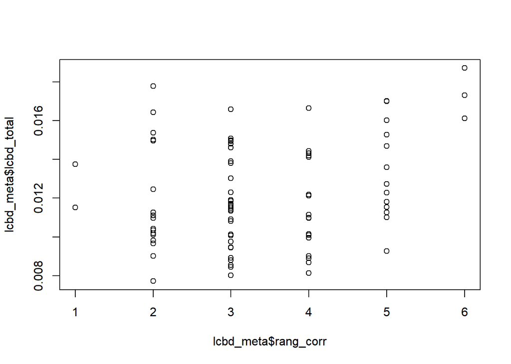

```r
plot(lcbd_meta$lcbd_total ~ lcbd_meta$rang_corr) #Ordem do rio
```

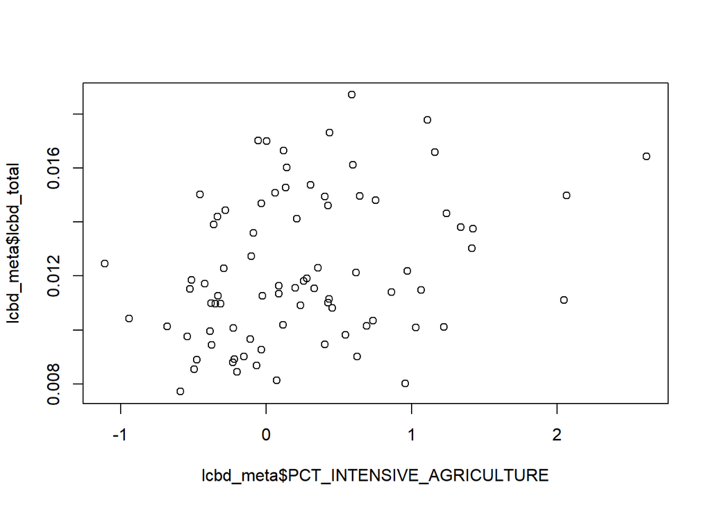

```r
plot(lcbd_meta$lcbd_total ~ lcbd_meta$PCT_INTENSIVE_AGRICULTURE) #Agricultura intensiva
```

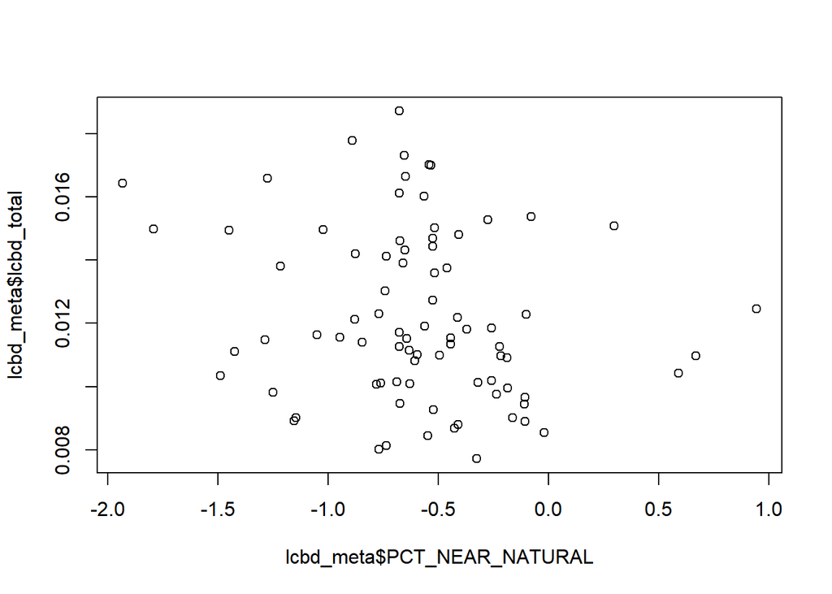

```r
plot(lcbd_meta$lcbd_total ~ lcbd_meta$PCT_NEAR_NATURAL) #Área natural
```

Nesta primeira visualização, nenhuma das variáveis parecem ter muita relação com o LCBD. Agora, vamos modelar esses dados.

## 6 Ajuste dos modelos GLM

Ajustamos dois modelos de distribuição **beta**:

- Apenas com as variáveis de uso do solo: agricultura intensiva, área natural, urbanização e floresta ripária.
- Apenas com as variáveis de características do rio: tipo e ordem do rio.

```r
model_beta1 <- glmmTMB(
  lcbd_total ~ PCT_INTENSIVE_AGRICULTURE + PCT_NEAR_NATURAL + PCT_URBAN + RIPAR30M_R,
  data = lcbd_meta,
  family = beta_family()
)

model_beta2 <- glmmTMB(
  lcbd_total ~ type + rang_corr,
  data = lcbd_meta,
  family = beta_family()
)
```

## 7 Comparação e diagnóstico dos modelos

Comparamos os modelos pelo **AIC** (Critério de Informação de Akaike): menor AIC indica melhor ajuste.

```r
AIC(model_beta1, model_beta2)
```

```
##             df       AIC
## model_beta1  6 -743.3241
## model_beta2  4 -744.2007
```

Observamos que o modelo 2 apresentou menor AIC, logo tem potencial de ser o modelo escolhido. Vamos avaliar outros aspectos…

Em seguida, vamos visualizar a relação dos dados observados com os preditos pelos modelos

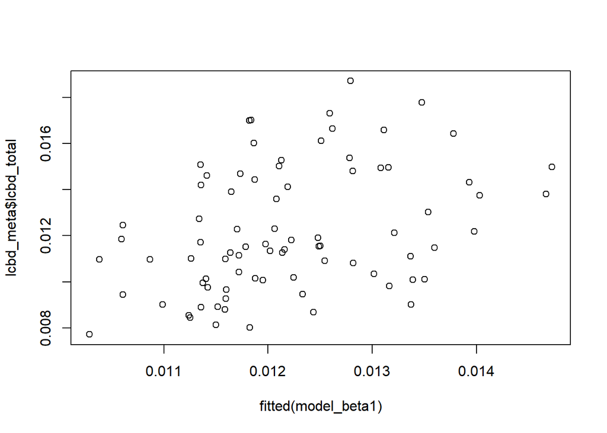

```r
plot(lcbd_meta$lcbd_total ~ fitted(model_beta1))
```

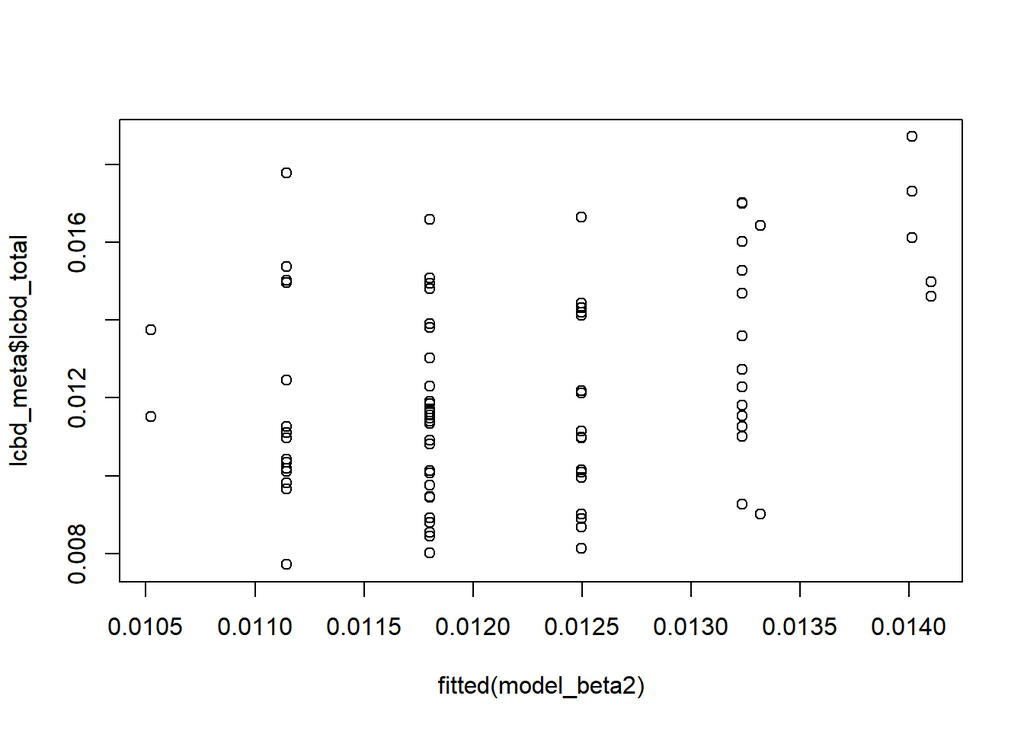

```r
plot(lcbd_meta$lcbd_total ~ fitted(model_beta2))
```

Nenhum modelo parece muito bom.

Agora utilizamos a função `simulateResiduals()` do pacote **DHARMa** para verificar resíduos simulados e a função `check_model()` do pacote **performance** para checar suposições gerais dos modelos.

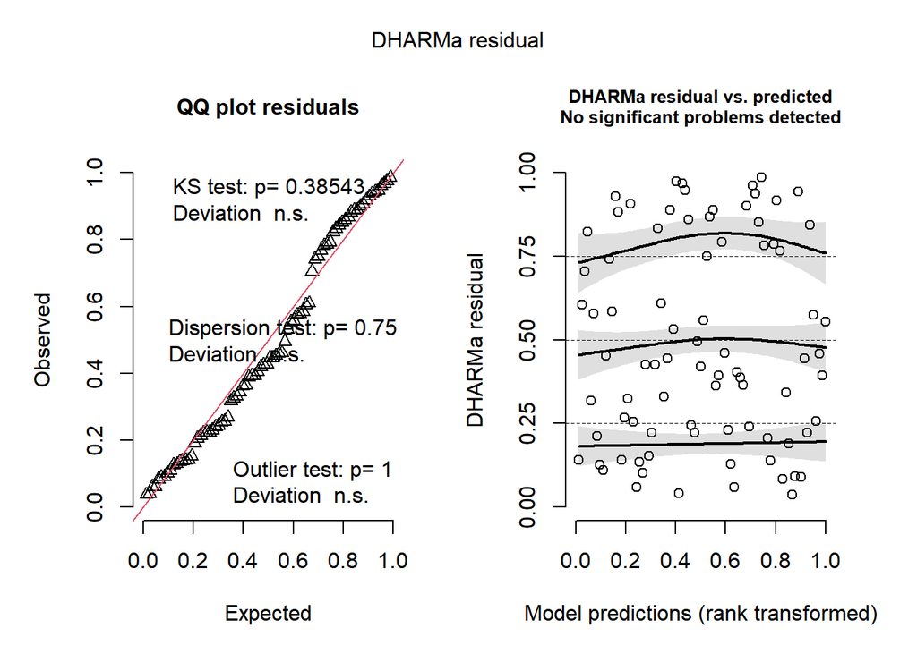

```r
res1 <- simulateResiduals(model_beta1, n = 1000, plot = TRUE) #Modelo uso do solo
```

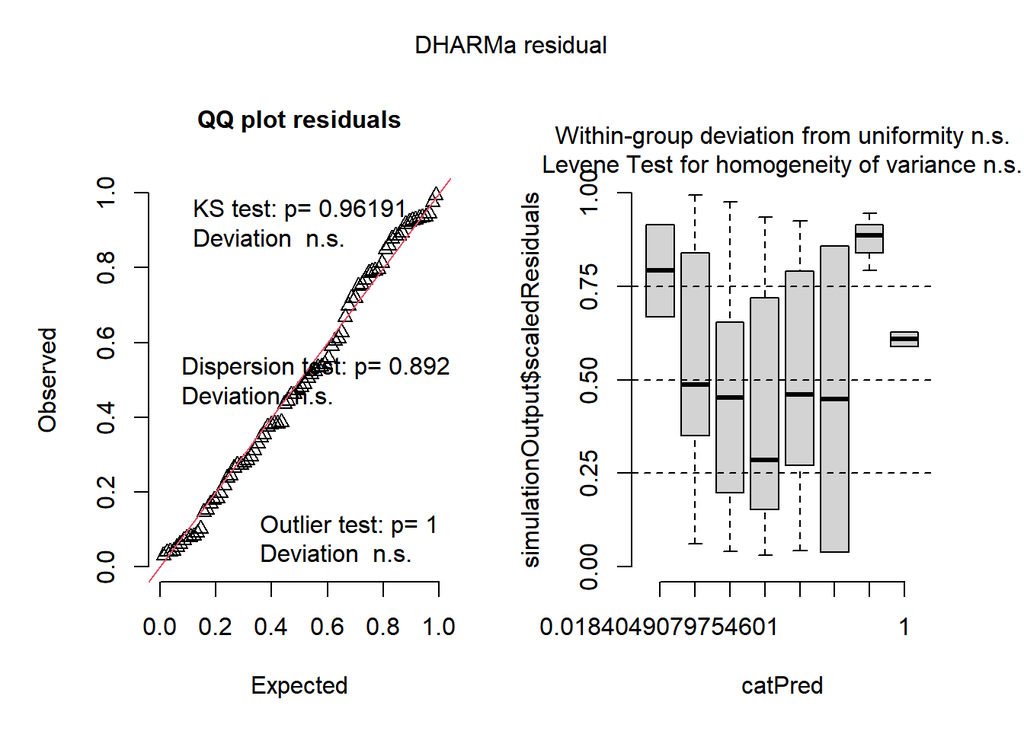

```r
res2 <- simulateResiduals(model_beta2, n = 1000, plot = TRUE) #Modelo características do rio
```

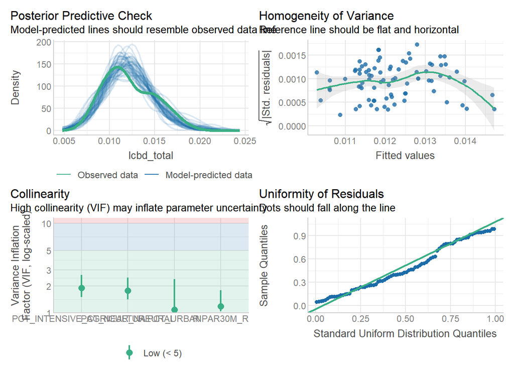

```r
check_model(model_beta1) #Modelo uso do solo
```

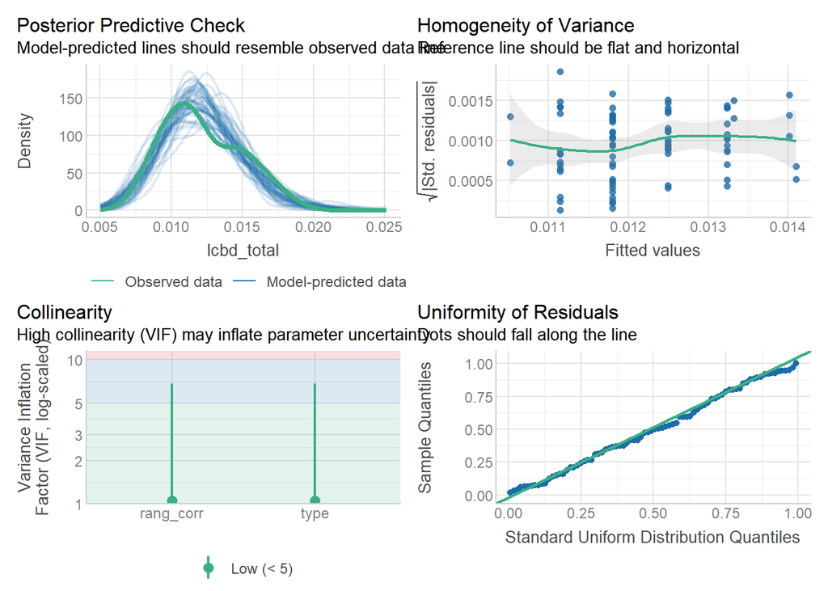

```r
check_model(model_beta2) #Modelo características do rio
```

De modo geral, não há uma diferença muito gritante entre os modelos. Vamos prosseguir com o modelo 2 que apresentou menor AIC e resíduos mais uniformes.

Vamos avaliar as relações das variáveis:

```r
summary(model_beta2)
```

```
##  Family: beta  ( logit )
## Formula:          lcbd_total ~ type + rang_corr
## Data: lcbd_meta
##
##       AIC       BIC    logLik -2*log(L)  df.resid
##    -744.2    -734.6     376.1    -752.2        78
##
##
## Dispersion parameter for beta family (): 1.92e+03
##
## Conditional model:
##             Estimate Std. Error z value Pr(>|z|)
## (Intercept) -4.42133    0.10994  -40.21  < 2e-16 ***
## typeper     -0.18031    0.10212   -1.77  0.07744 .
## rang_corr    0.05799    0.02071    2.80  0.00511 **
## ---
## Signif. codes:  0 '***' 0.001 '**' 0.01 '*' 0.05 '.' 0.1 ' ' 1
```

A ordem do rio parece importante para explicar o LCBD Total.

## 8 Visualização dos efeitos ajustados

Plotamos as predições com a função `ggpredict()` do pacote **ggeffects**.

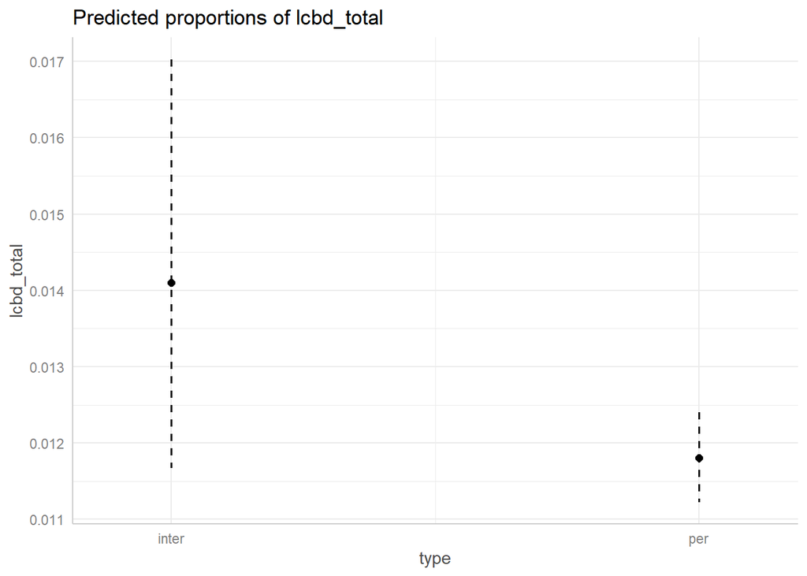

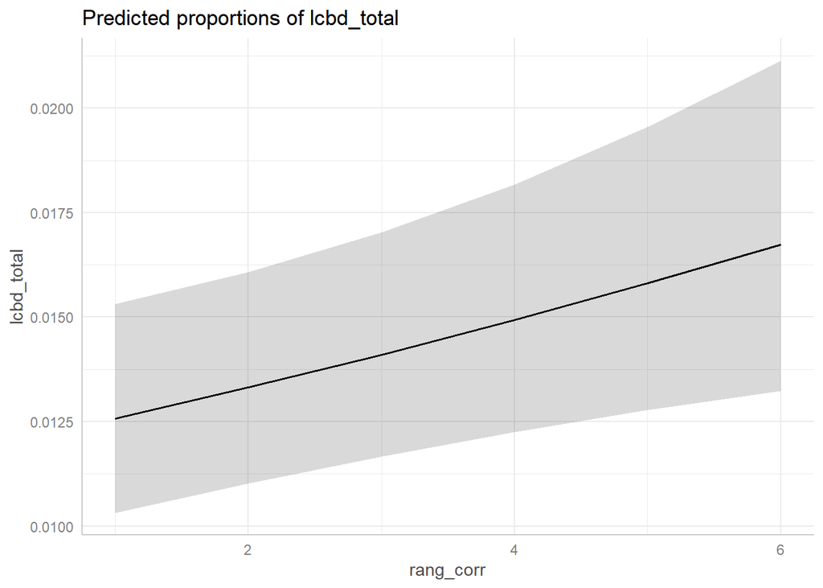

```r
ggpredict(model_beta2) %>% plot()
```

## 9 Autocorrelação espacial dos resíduos

Por fim, vamos verificar se há autocorrelação espacial nos resíduos do modelo escolhido.

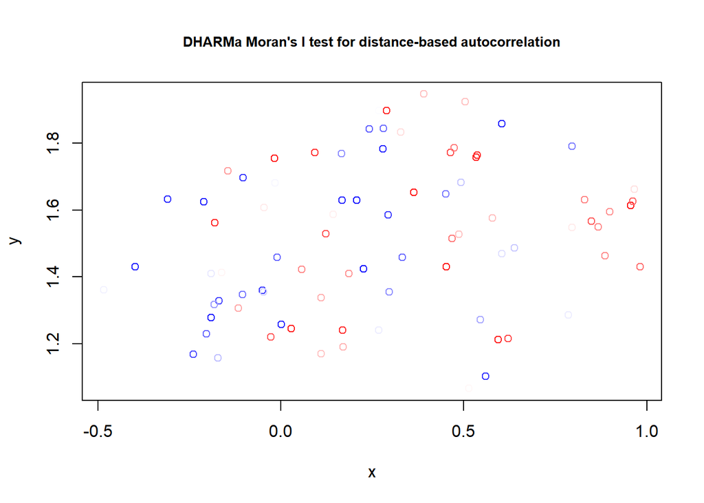

```
##
##  DHARMa Moran's I test for distance-based autocorrelation
##
## data:  res2
## observed = 0.076755, expected = -0.012346, sd = 0.024191, p-value =
## 0.0002303
## alternative hypothesis: Distance-based autocorrelation
```

```r
testSpatialAutocorrelation(res2, x = lcbd_meta$longitude, y = lcbd_meta$latitude)
```

O teste identificou autocorrelação espacial. Vamos tentar adicionar as variáveis de latitude e longitude no modelo e ver o que acontece com os resíduos:

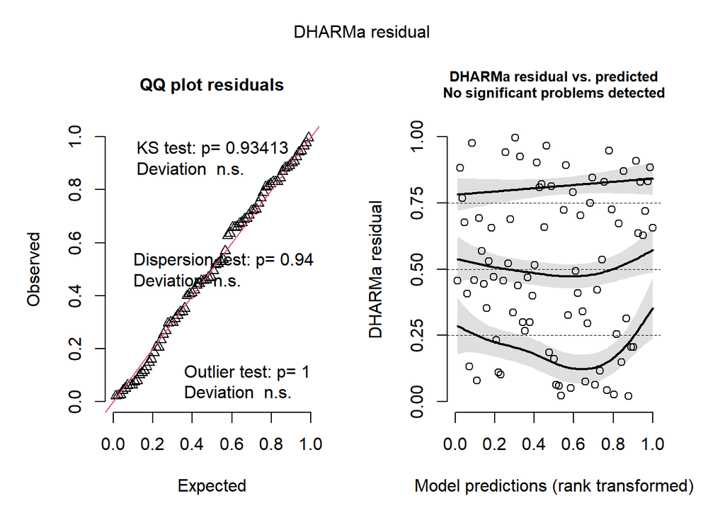

```r
model_beta<- glmmTMB(
  lcbd_total ~ type + rang_corr + latitude + longitude,
  data = lcbd_meta,
  family = beta_family()
)


resG <- simulateResiduals(model_beta, n = 1000, plot = TRUE)
```

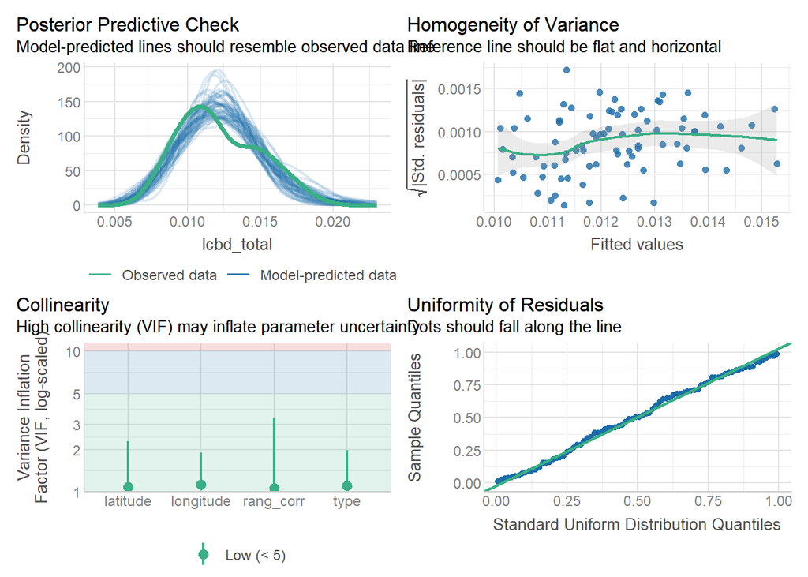

```r
check_model(model_beta)
```

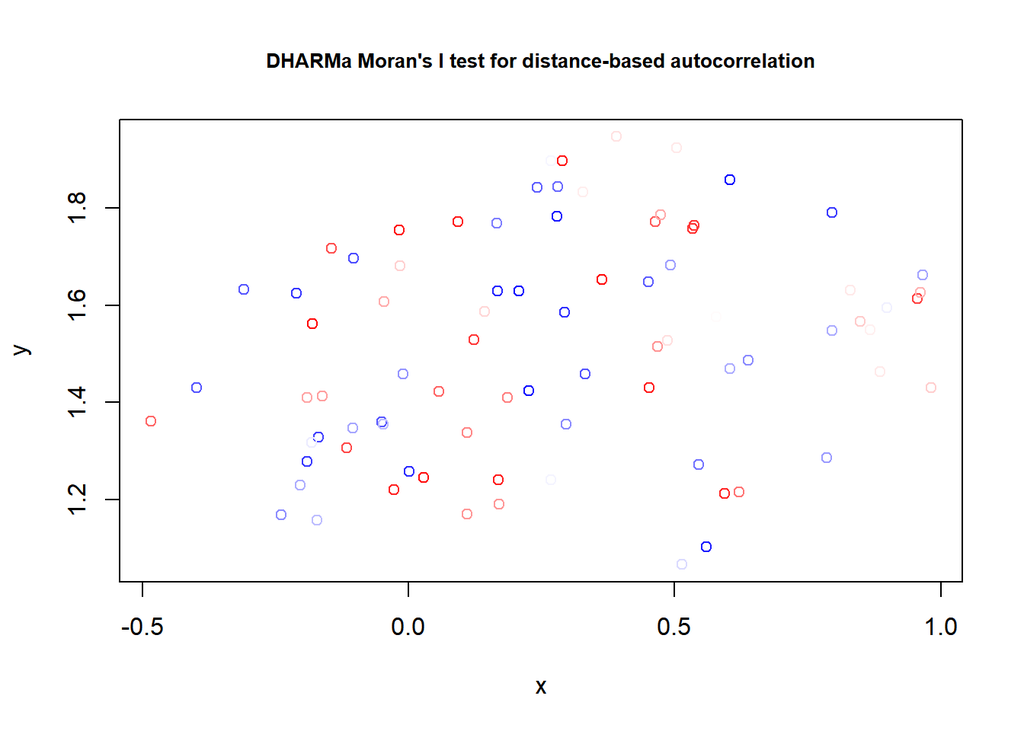

```
##
##  DHARMa Moran's I test for distance-based autocorrelation
##
## data:  resG
## observed = 0.0065466, expected = -0.0123457, sd = 0.0241879, p-value =
## 0.4348
## alternative hypothesis: Distance-based autocorrelation
```

```r
testSpatialAutocorrelation(resG, x = lcbd_meta$longitude, y = lcbd_meta$latitude)
```

```r
summary(model_beta)
```

```
##  Family: beta  ( logit )
## Formula:          lcbd_total ~ type + rang_corr + latitude + longitude
## Data: lcbd_meta
##
##       AIC       BIC    logLik -2*log(L)  df.resid
##    -750.2    -735.8     381.1    -762.2        76
##
##
## Dispersion parameter for beta family (): 2.17e+03
##
## Conditional model:
##             Estimate Std. Error z value Pr(>|z|)
## (Intercept) -4.40464    0.18304 -24.064  < 2e-16 ***
## typeper     -0.10003    0.09890  -1.011  0.31180
## rang_corr    0.05358    0.01934   2.771  0.00559 **
## latitude    -0.01797    0.10130  -0.177  0.85921
## longitude   -0.19464    0.06240  -3.119  0.00181 **
## ---
## Signif. codes:  0 '***' 0.001 '**' 0.01 '*' 0.05 '.' 0.1 ' ' 1
```

A adição da latitude e da longitude no modelo removeu a autocorrelação espacial, deixando o modelo com um melhor ajuste. Além disso, nesse contexto, a longitude tem um papel significativo para explicar o padrão de LCBD. Entretanto, ainda não é um modelo que descreveu perfeitamente os dados e talvez a adição ou remoção de variáveis melhore o modelo.

## 10 Conclusão

Neste script exploramos a modelagem de LCBD com GLMs usando a distribuição beta. Concluímos que a distribuição beta sem as variáveis de uso do solo apresentou um melhor ajuste aos dados, porém o modelo ainda pode melhorar com a adição ou remoção de variáveis.